# RepData Assignment 1

Mark Munsell

May 15, 2015

## Introduction

It is now possible to collect a large amount of data about personal movement using activity monitoring devices such as a Fitbit, Nike Fuelband, or Jawbone Up. These type of devices are part of the “quantified self” movement – a group of enthusiasts who take measurements about themselves regularly to improve their health, to find patterns in their behavior, or because they are tech geeks. But these data remain under-utilized both because the raw data are hard to obtain and there is a lack of statistical methods and software for processing and interpreting the data.

This assignment makes use of data from a personal activity monitoring device. This device collects data at 5 minute intervals through out the day. The data consists of two months of data from an anonymous individual collected during the months of October and November, 2012 and include the number of steps taken in 5 minute intervals each day.

```r
stepData <- read.csv(".//activity.csv")
stepData$date <- as.Date(stepData$date, "%Y-%m-%d")

stepData <- data.frame(date=stepData$date,
                       weekday=toupper(weekdays(stepData$date)),
                       steps=stepData$steps,
                       interval=stepData$interval)

stepData <- cbind(stepData,
                  daytype=ifelse(stepData$weekday == "SATURDAY" |
                                     stepData$weekday == "SUNDAY", "WEEKEND","WEEKDAY"))
stepDataFinal <- data.frame(Date=stepData$date,
                       Weekday=stepData$weekday,
                       DayType=stepData$daytype,
                       Interval=stepData$interval,
                       Steps=stepData$steps)

head(stepDataFinal)
```

```
##         Date Weekday DayType Interval Steps
## 1 2012-10-01  MONDAY WEEKDAY        0    NA
## 2 2012-10-01  MONDAY WEEKDAY        5    NA
## 3 2012-10-01  MONDAY WEEKDAY       10    NA
## 4 2012-10-01  MONDAY WEEKDAY       15    NA
## 5 2012-10-01  MONDAY WEEKDAY       20    NA
## 6 2012-10-01  MONDAY WEEKDAY       25    NA
```

## What is mean total number of steps taken per day?

```r
stepDayTotal <- aggregate(stepDataFinal$Steps, by=list(stepDataFinal$Date), FUN=sum, na.rm=TRUE)

names(stepDayTotal) <- c("Date", "Total")

head(stepDayTotal)
```

```
##         Date Total
## 1 2012-10-01     0
## 2 2012-10-02   126
## 3 2012-10-03 11352
## 4 2012-10-04 12116
## 5 2012-10-05 13294
## 6 2012-10-06 15420
```

## Histogram of the total number of steps per day:

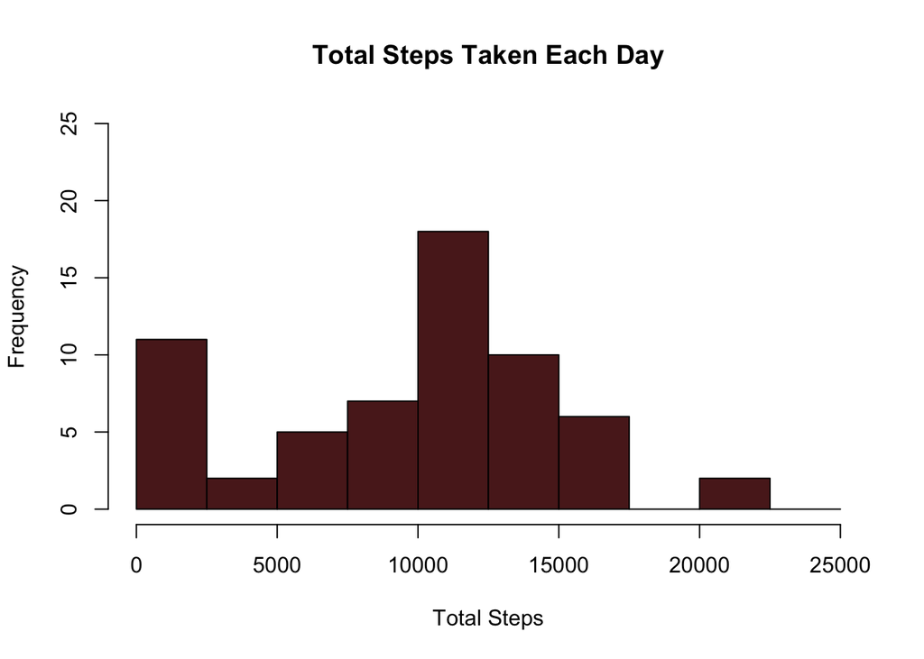

```r
hist(stepDayTotal$Total,
     breaks=seq(from=0, to=25000, by= 2500),
     col="#5a2121",
     xlab="Total Steps",
     ylim=c(0, 25),
     main="Total Steps Taken Each Day")
```

#### Here is the calculation for mean and median of total number of steps taken per day.

```r
stepMean <- mean(stepDayTotal$Total)

stepMed <- median(stepDayTotal$Total)
```

### The mean of the total number of steps is 9354.2295082 and the median is 10395.

## What is the average daily activity pattern?

Here is the code to create the data and the summary and first entries.

```r
stepIntMean <- aggregate(stepDataFinal$Steps,
                         by=list(stepDataFinal$Interval),
                         FUN=mean,
                         na.rm=TRUE)

names(stepIntMean) <- c("Interval", "Mean")


head(stepIntMean)
```

```
##   Interval      Mean
## 1        0 1.7169811
## 2        5 0.3396226
## 3       10 0.1320755
## 4       15 0.1509434
## 5       20 0.0754717
## 6       25 2.0943396
```

```r
summary(stepIntMean)
```

```
##     Interval           Mean
##  Min.   :   0.0   Min.   :  0.000
##  1st Qu.: 588.8   1st Qu.:  2.486
##  Median :1177.5   Median : 34.113
##  Mean   :1177.5   Mean   : 37.383
##  3rd Qu.:1766.2   3rd Qu.: 52.835
##  Max.   :2355.0   Max.   :206.170
```

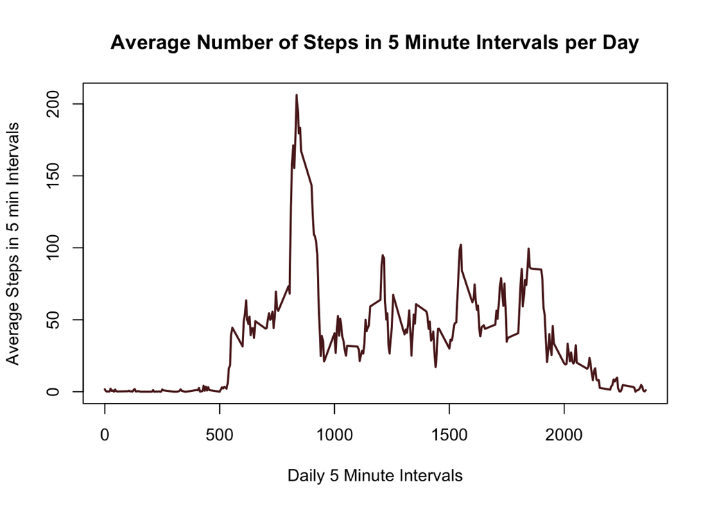

```r
plot(stepIntMean$Interval,
     stepIntMean$Mean,
     type="l",
     col="#5a2121",
     lwd=2,
     xlab="Daily 5 Minute Intervals",
     ylab="Average Steps in 5 min Intervals",
     main="Average Number of Steps in 5 Minute Intervals per Day")
```

Code to determine the interval with the maximum number of steps:

```r
maxIntPos <- which(stepIntMean$Mean == max(stepIntMean$Mean))

maxInt <- stepIntMean[maxIntPos,1]
```

### The 5-minute interval, on average across all the days in the dataset, that contains the maximum number of steps is 835

## Imputing the missing values

Note that there are a number of days/intervals where there are missing values (coded as NA). The presence of missing days may introduce bias into some calculations or summaries of the data.

Code to calculate the missing step data:

```r
naCount <- sum(is.na(stepDataFinal$Steps))
```

### The number of values coded with NA are: 2304

Here is the code the replace NA with the mean of steps:

```r
naPos <- which(is.na(stepDataFinal$Steps))

meanRep <- rep(mean(stepDataFinal$Steps, na.rm=TRUE), times=length(naPos))
```

```r
stepDataFinal[naPos, "Steps"] <- meanRep
```

Here are the first few rows of the new stepDataFinal data frame:

```r
head(stepDataFinal)
```

```
##         Date Weekday DayType Interval   Steps
## 1 2012-10-01  MONDAY WEEKDAY        0 37.3826
## 2 2012-10-01  MONDAY WEEKDAY        5 37.3826
## 3 2012-10-01  MONDAY WEEKDAY       10 37.3826
## 4 2012-10-01  MONDAY WEEKDAY       15 37.3826
## 5 2012-10-01  MONDAY WEEKDAY       20 37.3826
## 6 2012-10-01  MONDAY WEEKDAY       25 37.3826
```

## Histogram of the total number of steps per day with NA replaced with step mean value:

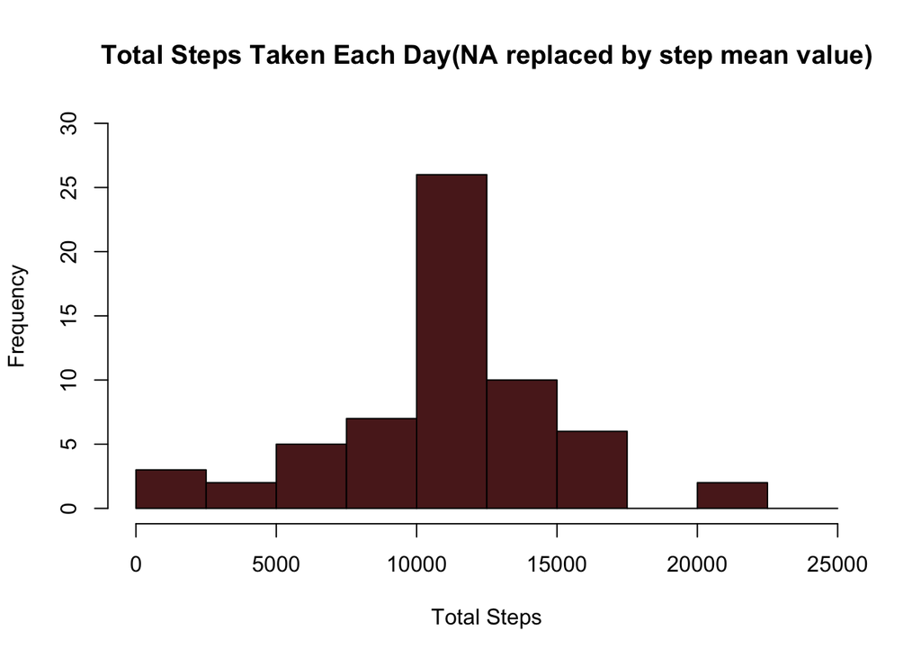

```r
stepDayTotal <- aggregate(stepDataFinal$Steps, by=list(stepDataFinal$Date), FUN=sum)

names(stepDayTotal) <- c("Date", "Total")


hist(stepDayTotal$Total,
     breaks=seq(from=0, to=25000, by= 2500),
     col="#5a2121",
     xlab="Total Steps",
     ylim=c(0, 30),
     main="Total Steps Taken Each Day(NA replaced by step mean value)")
```

#### Here is the new dataframe with new mean and median with NA replaced with steps mean.

```r
head(stepDayTotal)
```

```
##         Date    Total
## 1 2012-10-01 10766.19
## 2 2012-10-02   126.00
## 3 2012-10-03 11352.00
## 4 2012-10-04 12116.00
## 5 2012-10-05 13294.00
## 6 2012-10-06 15420.00
```

```r
 mean(stepDayTotal$Total)
```

```
## [1] 10766.19
```

```r
 median(stepDayTotal$Total)
```

```
## [1] 10766.19
```

## Are there differences in activity patterns between weekdays and weekends?

Here is the dataset with NA replaced by step mean and weekday and day type:

```r
head(stepDataFinal)
```

```
##         Date Weekday DayType Interval   Steps
## 1 2012-10-01  MONDAY WEEKDAY        0 37.3826
## 2 2012-10-01  MONDAY WEEKDAY        5 37.3826
## 3 2012-10-01  MONDAY WEEKDAY       10 37.3826
## 4 2012-10-01  MONDAY WEEKDAY       15 37.3826
## 5 2012-10-01  MONDAY WEEKDAY       20 37.3826
## 6 2012-10-01  MONDAY WEEKDAY       25 37.3826
```

```r
library(lattice)

mnData <- aggregate(stepDataFinal$Steps,
                    by=list(stepDataFinal$DayType,
                            stepDataFinal$Weekday,
                            stepDataFinal$Interval),mean)



names(mnData) <- c("DayType", "Weekday", "Interval", "Mean")
```

Here is the dataframe:

```r
head(mnData)
```

```
##   DayType  Weekday Interval     Mean
## 1 WEEKDAY   FRIDAY        0 8.307244
## 2 WEEKDAY   MONDAY        0 9.418355
## 3 WEEKEND SATURDAY        0 4.672825
## 4 WEEKEND   SUNDAY        0 4.672825
## 5 WEEKDAY THURSDAY        0 9.375844
## 6 WEEKDAY  TUESDAY        0 0.000000
```

## Time Series Plot:

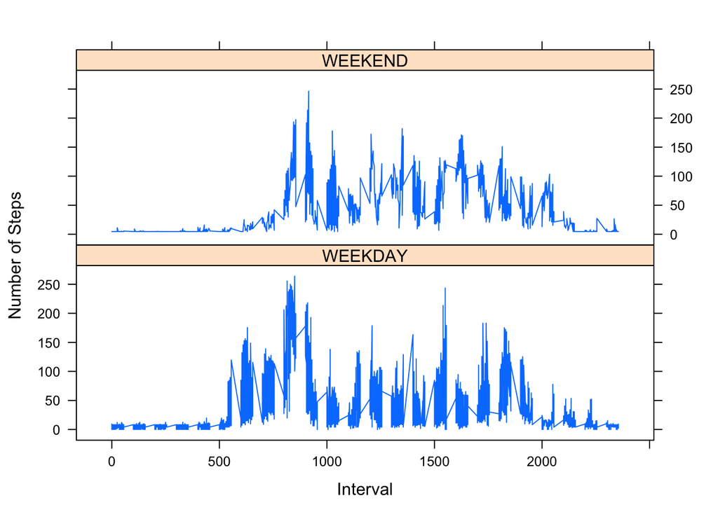

```r
xyplot(Mean ~ Interval | DayType, mnData,
       type="l",
       lwd=1,
       xlab="Interval",
       ylab="Number of Steps",
       layout= c(1,2))
```